# CA2_Farhan_PDS

Name: NAINAPILLAI SICKENDERSHA FARHAN Class: PDS Class 2 Admin No.:P2426066 DCPE/FT/2B/21

The Datasets used:

Dataset 1: Median Gross Monthly Income From Employment of FullTime Employed Residents (https://data.gov.sg/datasets/d_b4e4f1702eb5b9f61869f606dfee95ab/view)

Dataset 2: Consumer Price Index CPI 2019 As Base Year Annual (https://data.gov.sg/datasets/d_dcb352661fb449c4a4c0ab23aa8d6399/view)

Dataset 3: Water Prices Annual (https://data.gov.sg/datasets/d_f979ebe9adca8ac412a60d3f59b40f98/view)

Dataset 4: Electricity Tariff Annual (https://data.gov.sg/datasets/d_d610f8ed1864daa6c7e790318bbc3323/view)

Dataset 5: Resale flat prices based on registration date from Jan 2017 onwards (https://data.gov.sg/datasets/d_8b84c4ee58e3cfc0ece0d773c8ca6abc/view)

Dataset 6: Price Range of HDB Flats Offered (https://data.gov.sg/datasets/d_2d493bdcc1d9a44828b6e71cb095b88d/view)

## Topic Statement: Investigating the disparity between salary growth and the rising cost of living in Singapore

```python
# --- Import Libraries ---
import pandas as pd
import matplotlib.pyplot as plt
import seaborn as sns

# --- Load Datasets ---
wage_data = pd.read_csv("MedianGrossMonthlyIncomeFromEmploymentofFullTimeEmployedResidentsbySex.csv")

cpi_data = pd.read_csv("ConsumerPriceIndexCPI2019AsBaseYearAnnual.csv")

elec = pd.read_csv("ElectricityTariffAnnual.csv")

water = pd.read_csv("WaterPricesAnnual.csv")

resale = pd.read_csv('ResaleflatpricesbasedonregistrationdatefromJan2017onwards.csv')

bto = pd.read_csv("PriceRangeofHDBFlatsOffered.csv")
```

### Has wage growth been consistent, or are there “boom and flat” years?

```
=== Wage Dataset Summary ===
Number of rows: 44

Male:
  Income incl CPF: Lowest = 2449, Highest = 5460
  Income excl CPF: Lowest = 2176, Highest = 4875

Female:
  Income incl CPF: Lowest = 2204, Highest = 5070
  Income excl CPF: Lowest = 1950, Highest = 4333
```

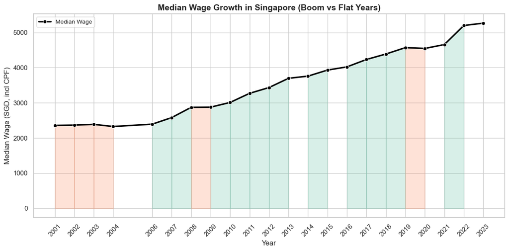

```python
sns.set_theme(style="whitegrid") # Set seaborn theme

print("=== Wage Dataset Summary ===") # dataset information and statistics
print("Number of rows:", len(wage_data))

for sex in ["male", "female"]: # Calculate and display wage ranges by gender
    subset = wage_data[wage_data["sex"].str.lower() == sex]
    high_incl = subset["med_income_incl_empcpf"].max()
    low_incl  = subset["med_income_incl_empcpf"].min()
    high_excl = subset["med_income_excl_empcpf"].max()
    low_excl  = subset["med_income_excl_empcpf"].min()
    print(f"\n{sex.capitalize()}:")
    print(f"  Income incl CPF: Lowest = {low_incl}, Highest = {high_incl}")
    print(f"  Income excl CPF: Lowest = {low_excl}, Highest = {high_excl}")

# Group by year and calculate average median wage across all demographics
avg_wage = (
    wage_data.groupby(["year"], as_index=False)["med_income_incl_empcpf"]
    .mean()
    .rename(columns={"year": "Year", "med_income_incl_empcpf": "Wage"})
)

avg_wage["Growth_Rate"] = avg_wage["Wage"].pct_change() * 100  # % change year to year

boom_threshold = 3   # Years with >3% growth considered "Boom"
flat_threshold = 1   # Years with <1% growth considered "Flat"

# Classify each year based on growth rate thresholds
conditions = []
for g in avg_wage["Growth_Rate"]:
    if pd.isna(g): # First year has no previous year to compare
        conditions.append("Start")
    elif g > boom_threshold:
        conditions.append("Boom")
    elif g < flat_threshold:
        conditions.append("Flat")
    else:
        conditions.append("Normal")

avg_wage["Period_Type"] = conditions # Add period classification

plt.figure(figsize=(12,6))

sns.lineplot(
    data=avg_wage,
    x="Year", y="Wage",
    marker="o", linewidth=2.5,
    color="black", label="Median Wage"
)

# Shade boom vs flat years
colors = {"Boom": sns.color_palette("Set2")[0],  # Green
          "Flat": sns.color_palette("Set2")[1]}  # Orange

# Add colored shading between consecutive years based on period type
for i in range(1, len(avg_wage)):
    year1, year2 = avg_wage["Year"].iloc[i-1], avg_wage["Year"].iloc[i]
    wage1, wage2 = avg_wage["Wage"].iloc[i-1], avg_wage["Wage"].iloc[i]
    period = avg_wage["Period_Type"].iloc[i]

    if period in colors: # Only shade boom and flat periods
        plt.fill_between(
            [year1, year2], [wage1, wage2],
            color=colors[period], alpha=0.25
        )


plt.title("Median Wage Growth in Singapore (Boom vs Flat Years)", fontsize=14, weight="bold")
plt.xlabel("Year", fontsize=12)
plt.ylabel("Median Wage (SGD, incl CPF)", fontsize=12)
plt.xticks(avg_wage["Year"].unique(), rotation=45)
plt.legend(frameon=True, fontsize=10)
plt.tight_layout()
plt.show()
```

The line graph clearly shows boom and bust cycles in Singapore's wage growth. 2001-2006 shows flat growth, most likely reflecting Singapore's recovery from the SARS outbreak in 2003, which had significantly impacted the economy. The sustained boom period from 2007-2017 corresponds to Singapore's economic expansion driven by the growth in financial services and infrastructure development. This growth was temporarily interrupted in 2008-2009 but quickly resumed and went on a upward trend till 2019. The flat periods in 2019-2020 align with global trade tensions and the disruption cause by COVID 19 pandemic. While the increase in 2021-2023 reflects post-pandemic recovery. Overall, the visualization demonstrates that Singapore's wage growth has not been consistent, with clear boom phases during periods of global economic expansion and flat growth period during international economic problems.